# Actual_Case_Count_Presentation_Version

## How many unreported COVID-19 cases are out there?

#### Because of home testing, closing of PCR sites, and less sequencing, epidemiologists believe official Covid-19 case counts are very likely to be under-reported.

#### Can we utilize additional data sources and machine learning to better predict what the actual case count is likely to be?

```python
# setting up the python environment, loading packages, and setting options
import numpy as np
import pandas as pd
import sklearn.ensemble
import matplotlib.pyplot as plt
from IPython.display import Image
from IPython.core.display import HTML
PATH = "/Users/matth/OneDrive/Documents/Personal Docs/Data Science/Science projects/Project wildfire/img/"
pd.set_option('display.max_columns',200)
```

### Defining how the world works

The first step in any data science project is to clearly delineate your assumptions about how things work and what's important. Data science is just a mathematical process of answering a question, so if your question sucks, your answer will too.

I like to draw pictures outlining the system I'm studying. I find that pictures are very easy to share and understand, and I believe science is at its best when everyone understands it.

Let's begin simply. Cases cause hospitalizations and deaths.

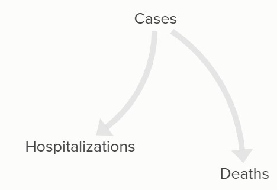

```python
Image(PATH +"diagram1.jpg", width =500, height=500)
```

In theory, this is enough to work backwards. Deaths are kinda hard to ignore, and hospitalizations due to COVID are still generally well-reported. If we understood the link between cases, hospitalizations, and deaths, and *that link never changed,* we'd be done.

Alas, we are not. We have a few confounding variables to account for, namely vaccinations and variants.

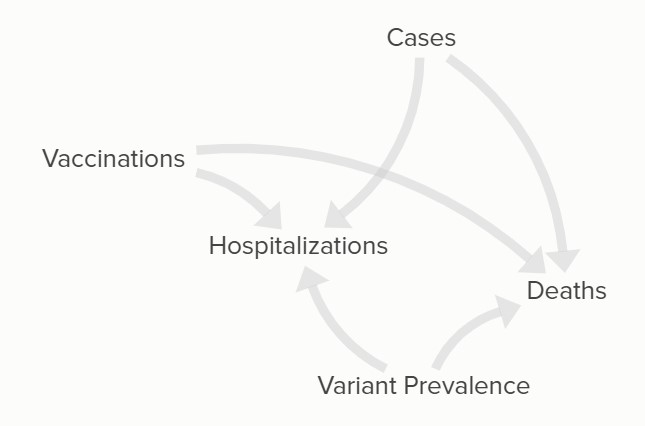

```python
Image(PATH + 'diagram2.jpg', width=500, height=500)
```

Vaccinations reduce the amount of people who die or end up in the hospital. The variant of COVID currently circulating also has an effect, though it's more complicated.

Omicron, for instance primarily affects the upper airway. In adults, this generally means fewer deaths (though only if you're vaccinated. Conversely, this same pattern of attack makes Omicron **much** more serious in children, as they have a narrower airway and are much more susceptible to airway restriction from inflammation.

These are both examples of additional factors that can affect the relationship between other variables in the model, so if we don't provide the model with information about these factors, we're very likely to get it wrong

Ok, let's continue to expand out our mental model of the world, at least as far as COVID spread is concerned.

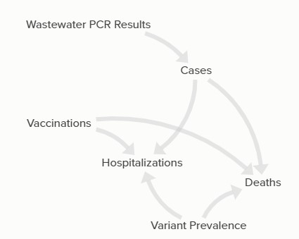

```python
Image(PATH + 'diagram3.jpg', width=500, height=500)
```

Wasterwater sampling is one promising area of development. As COVID is shed through fecal matter, water samples taken at wastewater processing facilities can be PCR-tested, which provides an indication of community spread in the area serviced by the treatment facility. So let's add that data in to our model.

What else? What about tests that are officially processed? If there are more cases in the wild, then when someone does have an official test done at a healthcare provider or hospital, it's probably more likely to be positive. So let's add in the positivity *rate*.

Note that we're not doing quantity here, we're looking at the number of positive tests divided by the number of tests overall. In general, we want to know rates, because that translates better to understanding the dynamics of the situation. 500 positive cases in New York City is a very different level of risk than 500 cases in Bandera, Texas, so to deal with that we have to normalize all of these variables by population. If you randomly pick 100,000 people, how many are positive? How many are hospitalized? How many die? How many were vaccinated?

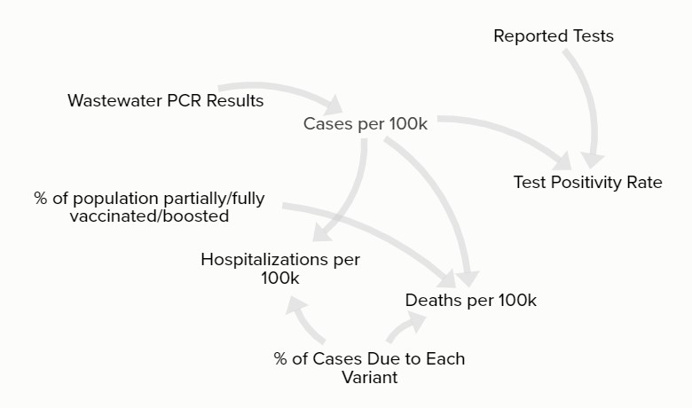

```python
Image(PATH + 'diagram4.jpg', width=800, height=800)
```

We also need to consider the human behavioral aspect. COVID is spread from person to person (obviously), so the more times people come in contact with each other, the higher the transmission rate must be. We could add in a ton of different measures here (number of air travelers by month, miles driven by month, etc), but generally they all normalize down to month. Our level of interpersonal contact varies by the month of the year, so let's make sure month is included.

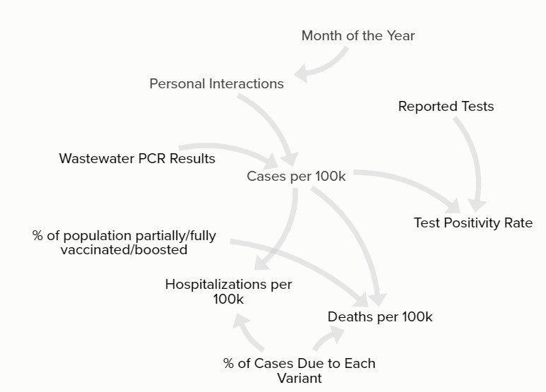

```python
Image(PATH+'diagram5.jpg', width=800, height=800)
```

Ok, so that's our mental model of the different factors affecting COVID cases per 100k people. Now if we can quantify all of the things which affect COVID cases, we'll (hopefully) be able to train a model to quantify the number of new daily cases per 100k people.

### Time to bring in the data

I assembled the data in a seperate Jupyter Notebook [here, as a web page](https://mattlscruggs.github.io/DataScienceRamblings/Actual_Case_Count_Data_Prep.html), and [here, as a Jupyter Notebook in the main repo](https://github.com/MattLScruggs/DataScienceRamblings), if you're curious about the details. Also, the data sources are linked on the home page.

```python
df=pd.read_csv("consolidated data- daily case count.csv")
```

Here's a preview of the data:

```python
df.head()
```

|  | date | month | year | Province_State | cases | deaths | hospitalized_covid | partial_vacc | full_vacc | vacc_boost | pcr_conc_smoothed | alpha_per | beta_per | gamma_per | delta_per | omicron_per | kappa_per | eta_per | iota_per | lambda_per | mu_per | eu1_per | epsilon_per | other_per | positive_rate | Census2019 | daily_new_cases_per_100k | daily_new_deaths_per_100k | daily_new_hosp_per_100k |
| --- | --- | --- | --- | --- | --- | --- | --- | --- | --- | --- | --- | --- | --- | --- | --- | --- | --- | --- | --- | --- | --- | --- | --- | --- | --- | --- | --- | --- | --- |
| 0 | 2020-01-22 | 1 | 2020 | Alabama | 0.0 | 0.0 | 0.0 | 0.0 | 0.0 | 0.0 | 0.0 | 0.0 | 0.0 | 0.0 | 0.0 | 0.0 | 0.0 | 0.0 | 0.0 | 0.0 | 0.0 | 0.0 | 0.0 | 0.0 | 0.0 | 658573.0 | 0.0 | 0.0 | 0.0 |
| 1 | 2020-01-22 | 1 | 2020 | Alaska | 0.0 | 0.0 | 0.0 | 0.0 | 0.0 | 0.0 | 0.0 | 0.0 | 0.0 | 0.0 | 0.0 | 0.0 | 0.0 | 0.0 | 0.0 | 0.0 | 0.0 | 0.0 | 0.0 | 0.0 | 0.0 | 288000.0 | 0.0 | 0.0 | 0.0 |
| 2 | 2020-01-22 | 1 | 2020 | Arizona | 0.0 | 0.0 | 0.0 | 0.0 | 0.0 | 0.0 | 0.0 | 0.0 | 0.0 | 0.0 | 0.0 | 0.0 | 0.0 | 0.0 | 0.0 | 0.0 | 0.0 | 0.0 | 0.0 | 0.0 | 0.0 | 4485414.0 | 0.0 | 0.0 | 0.0 |
| 3 | 2020-01-22 | 1 | 2020 | Arkansas | 0.0 | 0.0 | 0.0 | 0.0 | 0.0 | 0.0 | 0.0 | 0.0 | 0.0 | 0.0 | 0.0 | 0.0 | 0.0 | 0.0 | 0.0 | 0.0 | 0.0 | 0.0 | 0.0 | 0.0 | 0.0 | 391911.0 | 0.0 | 0.0 | 0.0 |
| 4 | 2020-01-22 | 1 | 2020 | California | 0.0 | 0.0 | 0.0 | 0.0 | 0.0 | 0.0 | 0.0 | 0.0 | 0.0 | 0.0 | 0.0 | 0.0 | 0.0 | 0.0 | 0.0 | 0.0 | 0.0 | 0.0 | 0.0 | 0.0 | 0.0 | 10039107.0 | 0.0 | 0.0 | 0.0 |

We have the following variables assembled from various sources across the internet (references above). The dimensions of our dataframe are:

```python
print(df.shape)
```

```
(42350, 29)
```

Or 42,350 observations of 29 variables.

Let's look at new daily cases (officially reported), hospitalizations, and deaths from Jan 2020 until now:

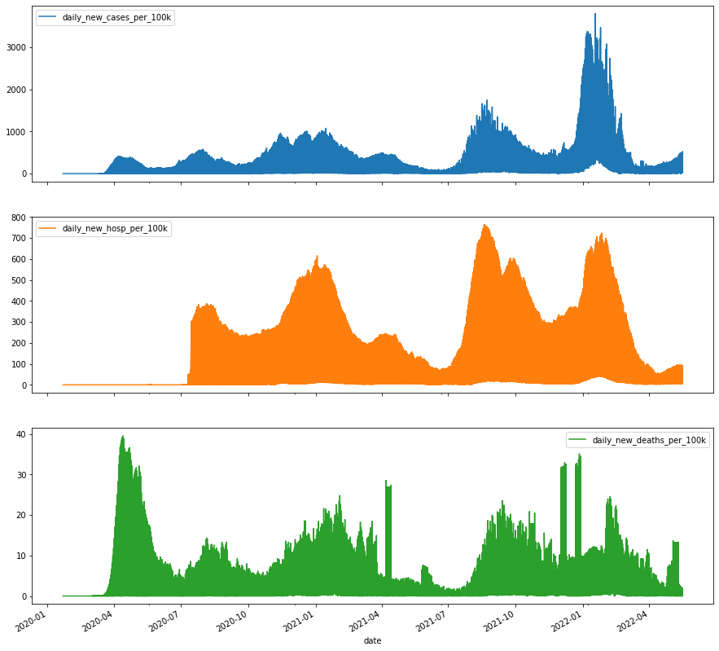

```python
df['month']=df['month'].astype("object")  #formatting date field as date
df['date']=pd.to_datetime(df['date'])     #plotting data
lp=df[['date','daily_new_cases_per_100k','daily_new_hosp_per_100k','daily_new_deaths_per_100k']].plot.line(x='date',figsize=(15,15),subplots=True)
plt.rc('font',size=12)
plt.show()
```

A few quick observations: The number of cases is definitely trending up across the years, while the hospitalization trend is trending up only slightly, and deaths is actually declining. That's excellent to see.

Before anyone starts shouting "But things were really serious in early 2022!", yes, they were. Remember, these figures are *normalized for population.* Out of 100k people, proportionally fewer are dying as time goes on (thanks, vaccines!). That **does not mean** that we don't have a public health crisis, if we have 20 million active COVID cases. Rates are important to understand for risk, but *volume* is what crushes healthcare systems. 1,000+ deaths per day is absolutely devastating, even if those deaths are coming as a lower overall fraction of the population.

```python
cat_data=df[['month','Province_State']]         #one-hot encoding categorical variables
cat_oh=pd.get_dummies(cat_data, drop_first=True)
df_oh=pd.concat([df,cat_oh], axis=1)
df_oh['log_cases']=np.log((df_oh['daily_new_cases_per_100k'].astype(int)+1))    #log transformation of variables-
df_oh['log_deaths']=np.log((df_oh['daily_new_deaths_per_100k'].astype(int)+1))  #these all have a power-law distribution
df_oh['log_hosp']=np.log((df_oh['daily_new_hosp_per_100k'].astype(int)+1))      #rather than a normal distribution
```

### Supervised learning in a nutshell

We're trying to understand the impact that freely available at home testing has on accuracy. Free tests became widely available starting on Jan 19th, with a 7-12 day shipping time. That means that any data after Feb 1 on cases could be skewed. So what we're going to do is first remove data after February 1. This is eventually what we're going to feed in to the finished model to get our *actual* number of new daily cases per 100k people, compared to what has been reported.

But hold on. How do we know that the predictions of cases after Feb 1 are valid? Couldn't the model be wrong, and spitting out nonsense?

Well, yes, but it won't, because we're going to train it. We have two major chunks of data:

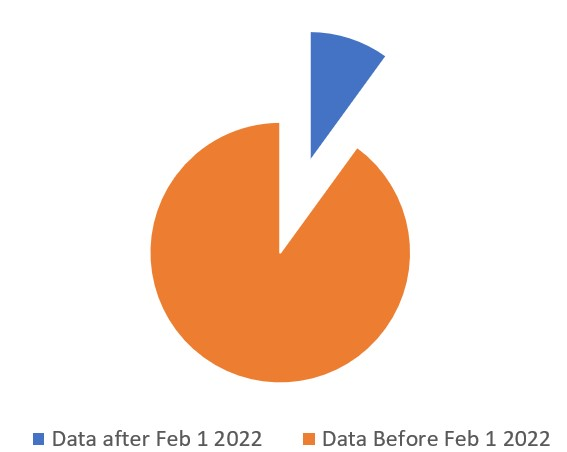

```python
Image(PATH + 'pie chart.jpg', width=450, height=450)
```

```python
prediction_set=df_oh[df_oh['date']>='2022-02-01'].sort_values(by='date').copy()  #segmenting data sets by date
learning_set=df_oh[df_oh['date']<'2022-02-01'].sort_values(by='date').copy()
```

We're taking the data post-Feb 2022 and setting it aside until the very end.

Now we're left with a big chunk, and we're going to split that again.

```python
y=learning_set['log_cases']                                                 #defining y (our target) and x (our predictors)
X=learning_set[['log_deaths', 'log_hosp', 'partial_vacc',
       'full_vacc', 'vacc_boost', 'pcr_conc_smoothed', 'alpha_per', 'beta_per',
       'gamma_per', 'delta_per', 'omicron_per', 'kappa_per', 'eta_per',
       'iota_per', 'lambda_per', 'mu_per', 'eu1_per', 'epsilon_per',
       'other_per', 'positive_rate','month_2', 'month_3', 'month_4', 'month_5', 'month_6',
       'month_7', 'month_8', 'month_9', 'month_10', 'month_11', 'month_12']]
from sklearn.preprocessing import StandardScaler
from sklearn.model_selection import train_test_split
scaler=StandardScaler()
X_scale=scaler.fit(X)
X_tx=X_scale.transform(X)                                                       #scale data by mean and standard deviation
X_train, X_test, y_train, y_test=train_test_split(X_tx, y, test_size=0.33, random_state=42)  #split training and testing
```

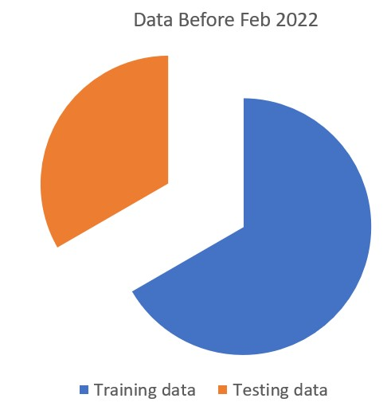

```python
Image(PATH+'pie chart 2.jpg', height = 350, width = 350)
```

The "training data" is a chunk we're taking out of our Pre-Feb 2022 data. It's a randomly selected 66% chunk. The idea is that the model learns the relationships between cases (our target variable) and everything else we put in the mental model diagram (our predictor variables) based on the training data we show it.

We then ask it to prove it knows the link with the testing data; this idea is exactly the same as studying textbooks, homework, and lecture notes (training data) and then taking a test (testing data). Once the model does well on the test, we know that it's smart enough to go out into the world and do useful things, like predicting Post-Feb 2022 cases.

If you're familiar with machine learning, you're probably asking "Matt, what about your validation set? How do you prevent data leakage and overfitting?" Fair points! I'm using a grid search cross-validation to tune and set my hyperparameters for all the models. The details of that are in the Jupyter notebook in the repo, if you want to dig into that.

### Model development

The model I'm ultimately going to end up using is a Random Forest, but to understand Random Forests, you have to understand a Decision Tree.

Decision Trees are ultimately flow charts; each node is a decision point, and you can look at a row of input data, judge it against the criteria in the node, and then choose the left or right branch. The final leaf in the tree holds the final prediction for the data.

The tree itself is built by choosing the best way to partition the input data so that each branch is more accurate than the brand above it. The tree then recursively improves itself until it either runs out of data points on each branch, or hits an artificial limit I place.

Let's build a small one, so the concept is clear.

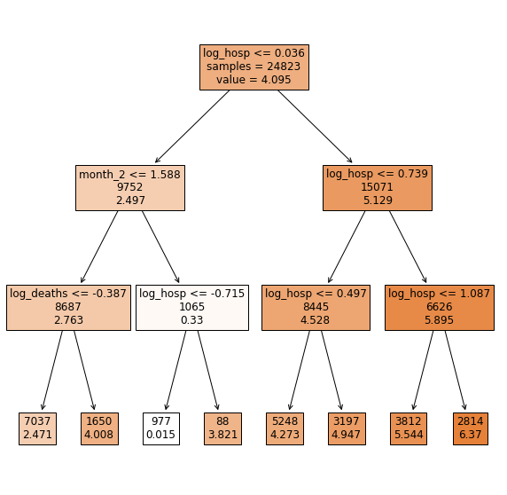

```python
from sklearn.tree import DecisionTreeRegressor
from sklearn import tree
features=['log_deaths', 'log_hosp', 'partial_vacc',
       'full_vacc', 'vacc_boost', 'pcr_conc_smoothed', 'alpha_per', 'beta_per',
       'gamma_per', 'delta_per', 'omicron_per', 'kappa_per', 'eta_per',
       'iota_per', 'lambda_per', 'mu_per', 'eu1_per', 'epsilon_per',
       'other_per', 'positive_rate','month_2', 'month_3', 'month_4', 'month_5', 'month_6',
       'month_7', 'month_8', 'month_9', 'month_10', 'month_11', 'month_12']           #define feature names
dt_reg = DecisionTreeRegressor(criterion='squared_error',max_depth = 3)        #shallow tree so its easy to diagram
dt_reg.fit(X_train, y_train)
plt.figure(figsize=(10,10))
tree.plot_tree(dt_reg,filled=True,
               max_depth=3,
               fontsize=12,
              feature_names=features,
              label='root',
              impurity=False)
plt.show()
```

One quick note before we start interpreting the rules- the data here has been log-transformed so that it approaches a normal distribution. I'll translate the values into normal numbers, but note that when you see "log_hosp" or "log_deaths" in the diagram, its referring to the natural log of those numbers, not the raw numbers.

This tree is initially asking us "is the number of daily new hospitalizations less than or equal to 1.05?" If yes, take the branch to the left. Otherwise, choose the branch on the right.

Let's pretend we go left. Now we have a new question to answer; is it February? If yes, go left, else go right.

Let's pretend it is, in fact, February. Now we ask, is the number of daily new deaths less than 0.68? If it is, this tree predicts that the daily new cases per 100k will be 12.2, otherwise the prediction is 54.9.

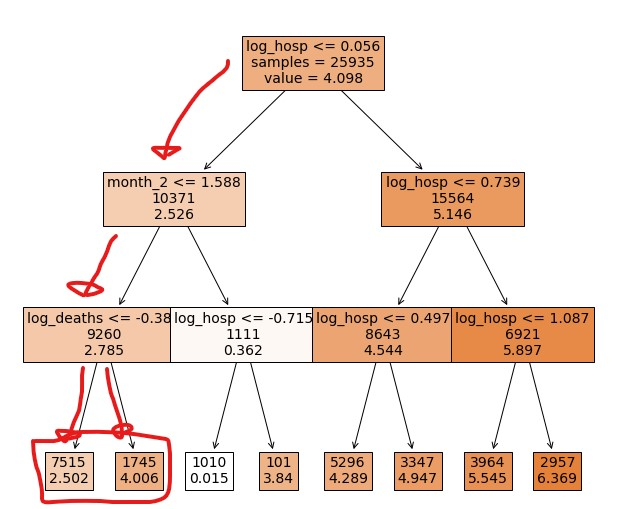

```python
Image(PATH+'tree path.jpg', width=500, height=500)
```

## Decision Tree Evaluation

This is probably an unfair test, since this is an extremely simple tree, but nevertheless, how well did it do on the test set?

```python
from sklearn.metrics import explained_variance_score
dt_pred=dt_reg.predict(X_test)
print("Our simple tree explained "+ \
      str(np.round(float(explained_variance_score(dt_pred, y_test)*100),decimals=2)) + \
      " percent of the variance.")
```

```
Our simple tree explained 70.99 percent of the variance.
```

Well, it passes the test, but just barely, explaining only about 70% of the cases it hasn't seen in the test set.

Let's check it visually on the historical data, and see how it's predictions did compared to actuals.

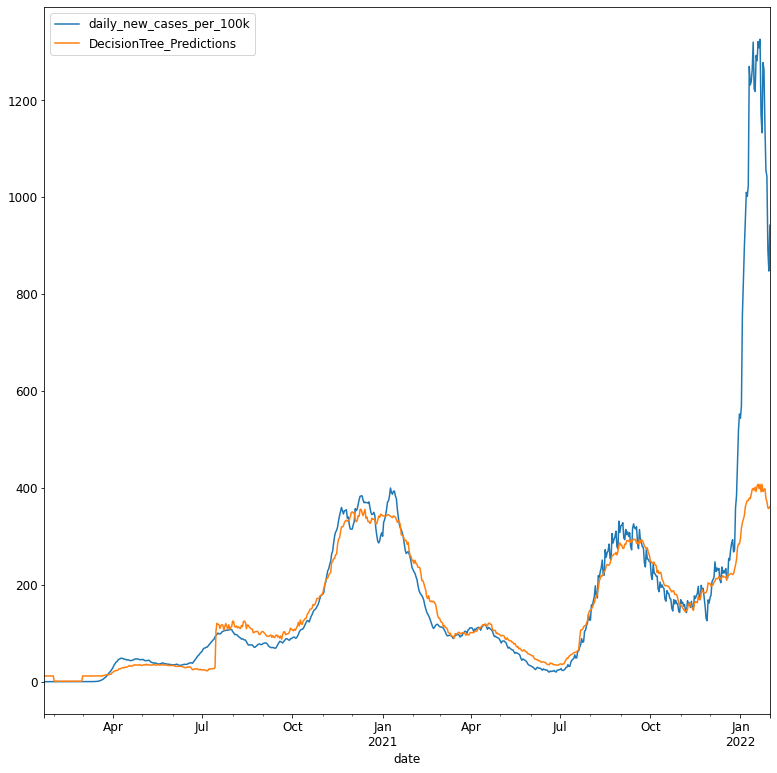

```python
actual_case_predictions=df_oh[['date','month','year','Province_State','daily_new_cases_per_100k']].copy()
actual_case_predictions['date']=pd.to_datetime(actual_case_predictions['date'])      #format historical data
pred_data=df_oh[['log_deaths', 'log_hosp', 'partial_vacc',                       #define, scale, and predict using historical
       'full_vacc', 'vacc_boost', 'pcr_conc_smoothed', 'alpha_per', 'beta_per',  #data and our decision tree model
       'gamma_per', 'delta_per', 'omicron_per', 'kappa_per', 'eta_per',
       'iota_per', 'lambda_per', 'mu_per', 'eu1_per', 'epsilon_per',
       'other_per', 'positive_rate','month_2', 'month_3', 'month_4', 'month_5', 'month_6',
       'month_7', 'month_8', 'month_9', 'month_10', 'month_11', 'month_12']].fillna(0).replace([np.inf,-np.inf], 0)
pred_tx=X_scale.transform(pred_data)
dt_predictions=dt_reg.predict(pred_tx)
actual_case_predictions['DecisionTree_Predictions']=np.exp(dt_predictions)
early_data=actual_case_predictions.loc[actual_case_predictions['date']<='2022-01-31'].copy()
early_data[['date','Province_State','daily_new_cases_per_100k','DecisionTree_Predictions']].groupby('date').\
mean().plot.line(figsize=(13,13))                                              #plotting the results
plt.rc('font',size=14)
plt.show()
```

That's directionally correct, but not great. This tree only had a max depth of 3, though. The goal was to make something easily explainable rather than correct, so the fact that this is actually probably somewhat useful is a nice bonus, and really shows the power of the tree-based models.

We could make a more complex tree, but instead the better path is to move to a Random Forest model.

## Now entering the Random Forest

A Random Forest model builds on the idea of a decision tree. In essence, it takes a **random** selection of the data and builds a decision tree, and then repeats the process until you're left with a **forest** of decision trees. The training data is evaluated on each tree, the resulting individual predictions are averaged to output a single final prediction.

A Random Forest model is, I think, pretty much always the second-best possible model for any prediction task. While XGBoost (or CatBoost, or LightGBM) might work better for peak performance on tabular data, and Convolutional Neural Nets rule the image processing world, and Recurrent Neural Nets work phenomenally for time-series data, you can pretty much throw anything into a Random Forest, and you'll get a pretty good outcome. It can handle missing data, blends of categorical and continuous data, non-standardized data, you name it. It's the Toyota Camry of machine learning models.

Let's build one. We're going to use a technique called grid search cross-validation to configure the model. I'm not going to go too far into the weeds, but essentially, machine learning models have what are called hyperparameters, which are basically configuration options for the model. We want the configuration which returns the best performance, but A) there are many many combinations to try manually, and B) we only have the training data to try it on. We absolutely cannot use the testing data, for the same reason that you can't help a student study by showing them the test over and over.

Grid search cross validation breaks our training data into a number of chunks (here I'm using 5), it builds a version of the model with one configuration using 4 of the 5 chunks, and validates the accuracy of that configuration on chunk number 5. Then it rotates which chunks it's using for learning and validation, until it's **validated** the configuration **across** combinations of the training data.

Then it repeats the same **cross-validation** process, but this time with a different configuration. All the different configurations are set up in a **grid**, hence **grid-search cross validation**.

```python
from sklearn.ensemble import RandomForestRegressor
rfr=RandomForestRegressor(n_jobs=-1)
rfr_grid=[{'n_estimators':[50,100,500,1000],
          'max_features':['sqrt','log2','auto',0.25],
          'oob_score':['True','False']}]
print(np.array(rfr_grid))
```

```
[{'n_estimators': [50, 100, 500, 1000], 'max_features': ['sqrt', 'log2', 'auto', 0.25], 'oob_score': ['True', 'False']}]
```

```python
from sklearn.model_selection import GridSearchCV
grid_search=GridSearchCV(rfr, rfr_grid,cv=5,scoring='neg_mean_squared_error',
                        return_train_score=True, n_jobs=-1, verbose=1)
grid_search.fit(X_train, y_train)
cv_results=grid_search.cv_results_
for mean_score, params in zip(cv_results["mean_test_score"],cv_results["params"]):  #print score for each parameter combo
    print(np.sqrt(-mean_score), params)
grid_search.best_params_                                                            #return best parameters
```

```
Fitting 5 folds for each of 32 candidates, totalling 160 fits
0.3500829872934091 {'max_features': 'sqrt', 'n_estimators': 50, 'oob_score': 'True'}
0.3497206684745697 {'max_features': 'sqrt', 'n_estimators': 50, 'oob_score': 'False'}
0.34884782384890495 {'max_features': 'sqrt', 'n_estimators': 100, 'oob_score': 'True'}
0.34890827094381954 {'max_features': 'sqrt', 'n_estimators': 100, 'oob_score': 'False'}
0.3484653698485393 {'max_features': 'sqrt', 'n_estimators': 500, 'oob_score': 'True'}
0.3483443843013504 {'max_features': 'sqrt', 'n_estimators': 500, 'oob_score': 'False'}
0.3482942749562124 {'max_features': 'sqrt', 'n_estimators': 1000, 'oob_score': 'True'}
0.3482116173939062 {'max_features': 'sqrt', 'n_estimators': 1000, 'oob_score': 'False'}
0.3492799535495185 {'max_features': 'log2', 'n_estimators': 50, 'oob_score': 'True'}
0.35010614257326755 {'max_features': 'log2', 'n_estimators': 50, 'oob_score': 'False'}
0.34946223816982824 {'max_features': 'log2', 'n_estimators': 100, 'oob_score': 'True'}
0.34833657865534645 {'max_features': 'log2', 'n_estimators': 100, 'oob_score': 'False'}
0.34842155533946084 {'max_features': 'log2', 'n_estimators': 500, 'oob_score': 'True'}
0.3485254391750884 {'max_features': 'log2', 'n_estimators': 500, 'oob_score': 'False'}
0.3481685333053739 {'max_features': 'log2', 'n_estimators': 1000, 'oob_score': 'True'}
0.3483315497918314 {'max_features': 'log2', 'n_estimators': 1000, 'oob_score': 'False'}
0.3553643204987339 {'max_features': 'auto', 'n_estimators': 50, 'oob_score': 'True'}
0.35536231724995176 {'max_features': 'auto', 'n_estimators': 50, 'oob_score': 'False'}
0.3552250396401801 {'max_features': 'auto', 'n_estimators': 100, 'oob_score': 'True'}
0.3551832966403213 {'max_features': 'auto', 'n_estimators': 100, 'oob_score': 'False'}
0.35478197505277714 {'max_features': 'auto', 'n_estimators': 500, 'oob_score': 'True'}
0.3546151859013365 {'max_features': 'auto', 'n_estimators': 500, 'oob_score': 'False'}
0.35464798564789896 {'max_features': 'auto', 'n_estimators': 1000, 'oob_score': 'True'}
0.35455902931730765 {'max_features': 'auto', 'n_estimators': 1000, 'oob_score': 'False'}
0.3499250924001579 {'max_features': 0.25, 'n_estimators': 50, 'oob_score': 'True'}
0.34995506468449245 {'max_features': 0.25, 'n_estimators': 50, 'oob_score': 'False'}
0.34880506269217054 {'max_features': 0.25, 'n_estimators': 100, 'oob_score': 'True'}
0.3486535134040618 {'max_features': 0.25, 'n_estimators': 100, 'oob_score': 'False'}
0.34853410515882266 {'max_features': 0.25, 'n_estimators': 500, 'oob_score': 'True'}
0.3486335748471448 {'max_features': 0.25, 'n_estimators': 500, 'oob_score': 'False'}
0.34858781882998036 {'max_features': 0.25, 'n_estimators': 1000, 'oob_score': 'True'}
0.34846425585579643 {'max_features': 0.25, 'n_estimators': 1000, 'oob_score': 'False'}
```

```
{'max_features': 'log2', 'n_estimators': 1000, 'oob_score': 'True'}
```

```python
rf_reg = RandomForestRegressor(criterion='squared_error',
                               n_estimators=1000,
                               max_features='log2',
                              oob_score = 'True')                               #use best configuration for final model
rf_reg.fit(X_train, y_train)
rfr_pred=rf_reg.predict(X_test)
print("Our Random Forest explained "\
      + str(np.round(float(explained_variance_score(rfr_pred, y_test)*100),decimals=2)) \
      + " percent of the variance.")
```

```
Our Random Forest explained 95.65 percent of the variance.
```

Much better! Our Random Forest model explains a little more than 95% of what you see. That's much better than our admittedly slapdash decision tree. Let's inspect visually against historical data.

## Comparing models across historical data

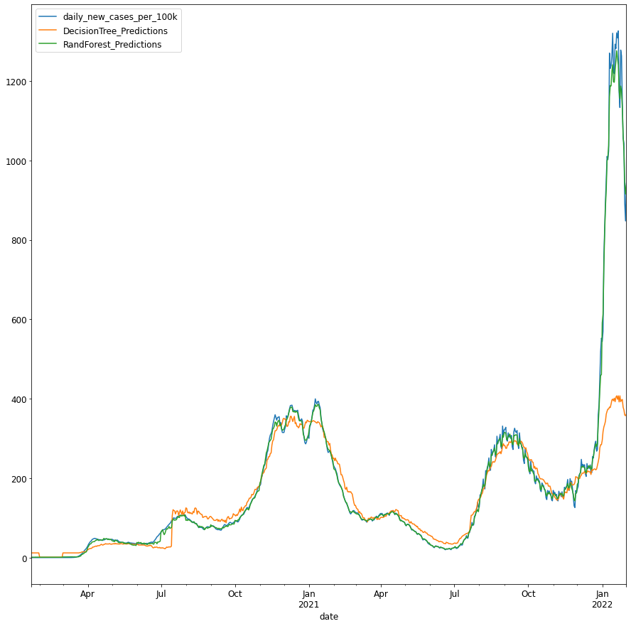

```python
rf_predictions=rf_reg.predict(pred_tx)
actual_case_predictions['RandForest_Predictions']=np.exp(rf_predictions)
early_data=actual_case_predictions.loc[actual_case_predictions['date']<='2022-01-31'].copy()
early_data[['date','Province_State','daily_new_cases_per_100k','DecisionTree_Predictions','RandForest_Predictions']].groupby('date').\
mean().plot.line(figsize=(15,15))
plt.rc('font',size=12)
plt.show()
```

That's a MUCH better fit to the pre-February data. In places it's hard to even see the blue line.

Now that we have a model that scored well on the test, let's set it out in to the world so it can determine how many COVID cases are actually out there.

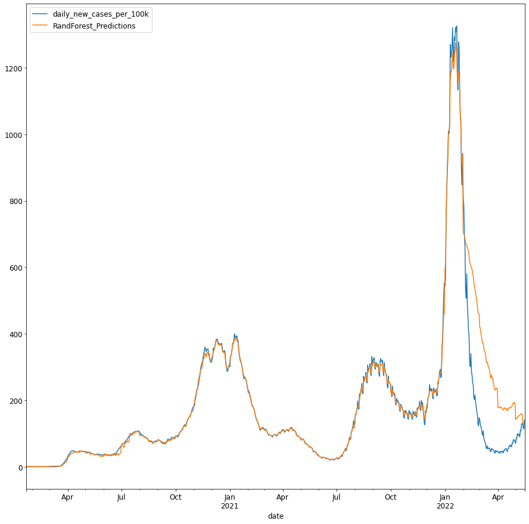

```python
actual_case_predictions[['date','Province_State','daily_new_cases_per_100k','RandForest_Predictions']].groupby('date').\
mean().plot.line(figsize=(15,15))
plt.rc('font',size=12)
plt.show()
```

Well, the Random Forest model picked up on the discrepancy, all right. There's a significant difference from Feb-April, indicated by how much higher the orange line (RF predictions) is than the blue line (reported totals).

We can peek at the actual reported cases vs predicted reported cases to look a bit closer at the discrepancy.

```python
actual_case_predictions[['date','Province_State','daily_new_cases_per_100k','RandForest_Predictions']].where((actual_case_predictions['date']<'2022-05-01') & (actual_case_predictions['date']>'2022-02-01')).groupby('date').mean().head(25)
```

| date | daily_new_cases_per_100k | RandForest_Predictions |
| --- | --- | --- |
| 2022-02-02 | 785.084205 | 699.903093 |
| 2022-02-03 | 697.999051 | 696.965434 |
| 2022-02-04 | 663.583506 | 685.403004 |
| 2022-02-05 | 534.189604 | 674.550073 |
| 2022-02-06 | 507.181313 | 669.577458 |
| 2022-02-07 | 580.045498 | 665.556673 |
| 2022-02-08 | 487.380842 | 658.471177 |
| 2022-02-09 | 453.535673 | 655.358432 |
| 2022-02-10 | 412.449578 | 644.330407 |
| 2022-02-11 | 387.994867 | 635.357810 |
| 2022-02-12 | 314.552262 | 616.235787 |
| 2022-02-13 | 300.983104 | 609.501172 |
| 2022-02-14 | 340.101933 | 603.876833 |
| 2022-02-15 | 286.057696 | 598.052327 |
| 2022-02-16 | 275.275986 | 594.481380 |
| 2022-02-17 | 253.783894 | 582.542714 |
| 2022-02-18 | 245.205668 | 573.478550 |
| 2022-02-19 | 209.138372 | 555.437218 |
| 2022-02-20 | 202.243001 | 544.398958 |
| 2022-02-21 | 215.543125 | 535.418837 |
| 2022-02-22 | 194.917293 | 525.441496 |
| 2022-02-23 | 179.694958 | 513.155769 |
| 2022-02-24 | 165.607205 | 499.025961 |
| 2022-02-25 | 157.535677 | 486.012275 |
| 2022-02-26 | 129.866690 | 466.849286 |

### How do these predictions help us understand the risk of exposure?

Covid patients start showing symptoms 3-6 days after exposure, and are contagious the whole time, from exposure to appx 10 days after symptoms end. Symptoms last appx 10 days. So 3 + 10 + 10 = 23 days of contagion.

Let's look at row 2022-02-20. There are 202 officially reported new cases per 100k people that day. Let's think about this from a patient perspective. Those 202 people were contagious for about three days before they got tested and recorded. So it stands to reason that the actual case count should include people up to three days in the future, since they are active cases that just haven't started showing symptoms yet. The actual total for 2022-02-20 would then be 202 + 215 (cases tested 1 day in the future) + 195 (two days) + 179 (three days) = 791 cases per 100k people. I know you can spread covid for up to 6 or so days before showing symptoms, but I'm being conservative.

But wait, there's more! You will also continue to be contagious for 10 days after symptoms stop, and symptoms last appx 10 days, so we need to look backward and count all the new cases from the past 20 days, as these people are still contagious, active cases.

202 (new cases reported on the date we're interested in) + 215 + 195 + 179 (looking forwards) + 209 + 245 + 253 + 275 + 286 + 340 + 301 + 315 + 387 + 412 + 453 + 487 + 580 + 507 + 534 + 663 + 698 + 785 (looking backwards) = 8,526 cases per 100k people. Let's verify my addition by adding it directly:

```python
mean_cases=actual_case_predictions[['date','Province_State','daily_new_cases_per_100k','RandForest_Predictions']].where(
    (actual_case_predictions['date']<'2022-02-24') & (actual_case_predictions['date']>'2022-02-01')).groupby(
    'date').mean().copy()
print("There were " + str(int(mean_cases['daily_new_cases_per_100k'].sum())) + \
      " officially reported contagious cases between Feb 01 and Feb 24.")
```

```
There were 8526 officially reported contagious cases between Feb 01 and Feb 24.
```

That's about 8.5% of the population. *And that's the reported counts.* How many did our Random Forest model infer that there actually are?

```python
print("There were actually " + str(int(mean_cases['RandForest_Predictions'].sum())) + \
      " contagious cases between Feb 01 and Feb 24.")
```

```
There were actually 13537 contagious cases between Feb 01 and Feb 24.
```

Let's calculate what cases are like now. I'm using the most current dates with data available, and I'll update regularly.

I'll also give people the benefit of the doubt. Let's just total the cases before symptoms start, and assume everyone quarantines during the symptomatic period, stays isolated the entire time, and doesn't emerge until they're no longer contagious.

Don't look at me like that. It could happen.

```python
import datetime
current_cases=actual_case_predictions[['date','Province_State','daily_new_cases_per_100k','RandForest_Predictions']].where(
    (actual_case_predictions['date']<'2022-05-06') & (actual_case_predictions['date']>'2022-05-01')).groupby(
    'date').mean().copy()
print("There are actually " + str(int(current_cases['RandForest_Predictions'].sum())) + \
      " contagious cases currently active, but only " + str(int(current_cases['daily_new_cases_per_100k'].sum())) + \
      " reported.")
```

```
There are actually 632 contagious cases currently active, but only 364 reported.
```

Certainly better than the peak, but still about 0.6% of the population, compared to the 0.3% currently reported.

### What is the model using to build its predictions?

This is another important step in the model building process, and one I'm very passionate about: explainable AI. Having algorithms show their work is vitally important in building trust for everyone.

Random Forests have a built-in method for permutation feature importance. It removes one variable, re-runs the model, and calculates how much *worse* it's predictions get without the variable it removed. A very important variable is one that totally screws up the model when it's removed.

This provides an important sanity check. If the model is using a completely unexpected variable to build its predictions, one for which there's no logic or reason to why it should predict well, then that suggests we need to take a closer look at what the model is doing.

So what is our Random Forest looking at?

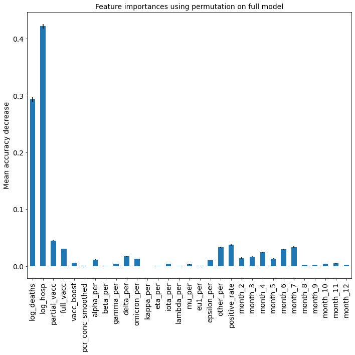

```python
from sklearn.inspection import permutation_importance
feature_names=X.columns.tolist()
imp_result=permutation_importance(                                  #calculate importance
    rf_reg, X_test, y_test, n_repeats=10, random_state=42, n_jobs=-1)
rf_importance=pd.Series(imp_result.importances_mean, index=feature_names)
fig, ax = plt.subplots(figsize=(10,10))
rf_importance.plot.bar(yerr=imp_result.importances_std, ax=ax, fontsize=14)
ax.set_title("Feature importances using permutation on full model", fontsize = 14)
ax.set_ylabel("Mean accuracy decrease", fontsize=14)
fig.tight_layout()                                                 #plot the important variables
plt.show()
```

Looks like the most important factors are hospitalizations and deaths, which makes intuitive sense and jibes with the diagram we drew from first principles. It also does seem to need vaccinations, variants (though some are more important than others), and month of the year.

I read somewhere that we don't need exact percentages to make decisions, just a rank-ordering of important factors. So here's your back-of-the-napkin summary:

- Cases are almost twice as high as reported
- If hospitalizations go up, cases are going up too, and faster than you think
- Ditto deaths due to covid
- If a variant comes out that's more contagious than omicron, cases are going to go up faster than they seem
- If the positivity rate of tests being recorded is going up, cases are going up too

## But how does knowing the number of contagious cases help us understand risk?

The number of contagious people per 100k determines (on average) how many infected people you're likely to encounter for any given number of people you see each day.

The idea is similar to drawing names from a hat, but in this case it's drawing random people from the population, and some of the people have COVID. For any given number of people, what is the probability that at least one has COVID?

This is especially important in a time when there are no mask mandates. If you have a collection of, let's say, 50 people at an event, indoors, without masks, how many people are likely to have COVID?

Conversely, for any given gathering size, what's the likelihood that at least one person has COVID?

### Binomial distribution to the rescue!

The binomial distribution generates the probabilities associated with questions like these. Given a number of random draws **n** and a probability of success **p**, what is the probability of a given number of successes **r**?

What we want to do is attach a probability to being exposed to *at least one* person with COVID out of a set number of people we encounter.

```python
p=0.006  #probability of active COVID infection (from model)
```

Let's look at the probability of exposure after interacting with 5 people.

```
Number of COVID infections 	 Probability
		0		0.97
		1		0.03
		2		0.0
		3		0.0
		4		0.0
		5		0.0
```

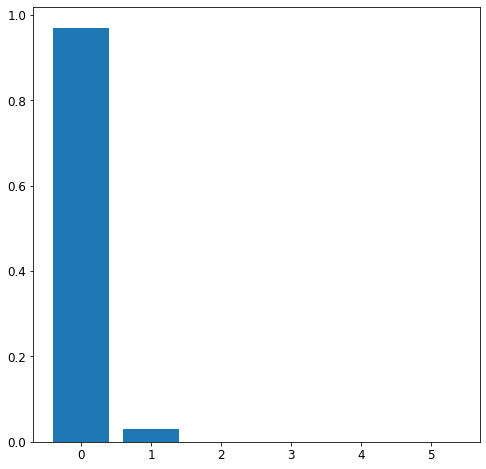

```
Probability of no one (0 people) having COVID: 97.0%
```

```python
from scipy.stats import binom
n = 5                             #number of people you interact with
r_values = list(range(n + 1))
mean, var = binom.stats(n, p)
dist = [binom.pmf(r, n, p) for r in r_values ]
print("Number of COVID infections \t Probability")
for i in range(n + 1):
	print("\t"+"\t"+str(r_values[i])+"\t"+ "\t"+ str(np.round(dist[i],2)))

plt.rc('font',size=12)
plt.figure(figsize=(8,8))
plt.bar(r_values, dist)
plt.show()
print("Probability of no one (0 people) having COVID: " + str((np.round(dist[0],2)*100)) + "%")
```

The height of the bar indicates the probablility of that number of people at the gathering having COVID, given a random selection from a population.

What this means is that if you interact, in person, with 5 people, statistically speaking there is a 97% chance that none of them will have COVID.

That's pretty good, but we have to remember that probabilities are cumulative, and there's no reset button. If we meet with another 5 people, we have another 97% chance of not being exposed from those 5 individuals, but only a 94% chance of *never* being exposed across all 10 people (97% * 97% = 94%).

We can also calculate that directly by setting the number of people to 10:

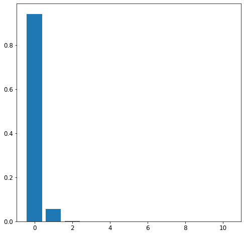

```
Probability of no one having COVID: 94.0%
```

```python
n = 10                            #number of people encountered
r_values = list(range(n + 1))
mean, var = binom.stats(n, p)
dist = [binom.pmf(r, n, p) for r in r_values ]
plt.rc('font',size=12)
plt.figure(figsize=(8,8))
plt.bar(r_values, dist)
plt.show()
print("Probability of no one having COVID: " + str((np.round(dist[0],2)*100)) + "%")
```

Ok, let's put this in a realistic context. Let's imagine you go out to eat with a friend or your spouse on a Friday night. You wear a mask while you wait, but take it off to eat. If there are 10 tables at the restaurant, an average of 3 people at each table, 3 servers covering the tables, one host/hostess, and 2 people busing the tables, that's a total of 36 people you're enclosed with, assuming people are waiting for tables outside or masked.

The next day, you run to the store, pass closely by 3 people in the aisles, stand in line to checkout with someone in front of you, someone behind you, the checkout clerk, and the bagger. That's 7 people, so now we're at 43 total, over the past two days.

The next day you meet up with a group of 5 friends for lunch and drinks. It's an outdoor dining area, so you're really only interacting with the host/hostess and the server. That brings the total to 7 + 43 = 50 people.

What is the probability that you've been exposed to COVID?

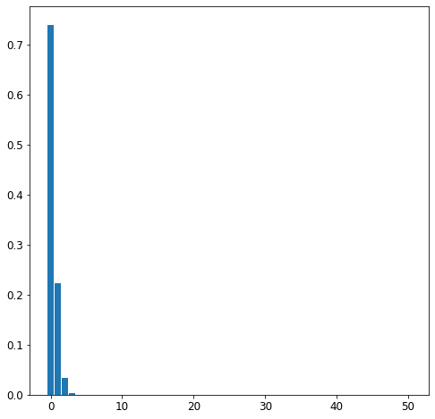

```
Probability of being exposed after a 'normal' weekend: 26.0%
```

```python
n = 50                           #number of people in the gathering
r_values = list(range(n + 1))
mean, var = binom.stats(n, p)
dist = [binom.pmf(r, n, p) for r in r_values ]
plt.rc('font',size=12)
plt.figure(figsize=(8,8))
plt.bar(r_values, dist)
plt.show()
print("Probability of being exposed after a 'normal' weekend: " + str(100-(np.round(dist[0],2)*100)) + "%")
```

I will note that I'm making one big assumption here: I'm assuming the probability per encounter is random, and I'm assuming a Markovian state that is essentially memoryless.

In actuality, if you meet up with friends, who themselves have also had a "normal" weekend, their likelihood of infection is not the baseline 0.6%, but closer to the 26% figure, since *they've also been exposed all weekend*. I'm giving everyone the maximum benefit of the doubt.

The takeaway is that behaving like there's no pandemic increases your risk of exposure 10x, and that's for one weekend.

Let's assume that you run into 50 people the next weekend, and the weekend after, etc, for a month. And let's say your normal weekly activities bring you in contact with 10 people, once a week. That brings each week to 60 people, which is 240 people per month. What does that do to your risk of exposure?

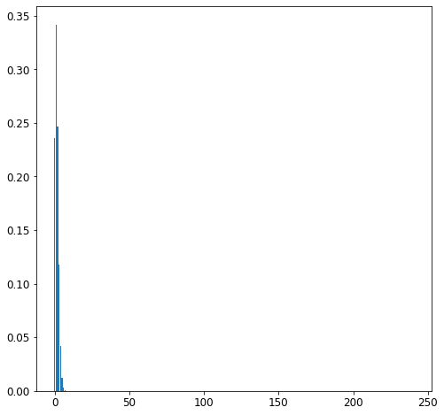

```
Probability of being exposed after a 'normal' month: 76.0%
```

```python
n = 240
r_values = list(range(n + 1))
mean, var = binom.stats(n, p)
dist = [binom.pmf(r, n, p) for r in r_values ]
plt.rc('font',size=12)
plt.figure(figsize=(8,8))
plt.bar(r_values, dist)
plt.show()
print("Probability of being exposed after a 'normal' month: " + str(100-(np.round(dist[0],2)*100)) + "%")
```

This is why public health measures like masks and social distancing are still important. *If you're wearing a properly-fitting N95 mask*, one exposure is unlikely to cause a problem. Given the mutated contagiousness of all the Omicron family, including BA4 and BA5, one *unmasked* exposure is *very* likely to cause infection.

We don't have accurate case numbers being reported, so the next wave will catch us unprepared. COVID is continuing to mutate, we are a long way from herd immunity, and evolution doesn't stop. Collectively we're behaving as if things have gone back to normal, which is precisely what's keeping things from going back to normal.

Let's imagine for a minute that probability of infection wasn't its current value of 0.6%, but instead was closer to the February peak of 13.5%. This is very likely if there is a new, more communicable strain, especially if that strain hits during peak months, and especially with the current lack of mandatory public health measures in the US. What is the risk of exposure during *one weekend* during a peak?

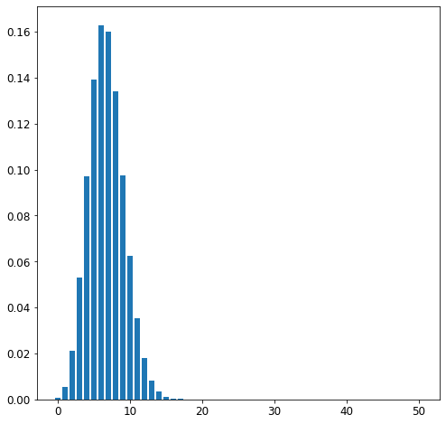

```
Probability of being exposed after a 'normal' weekend: 100.0%
```

```python
n = 50
p=0.135
r_values = list(range(n + 1))
mean, var = binom.stats(n, p)
dist = [binom.pmf(r, n, p) for r in r_values ]
plt.rc('font',size=12)
plt.figure(figsize=(8,8))
plt.bar(r_values, dist)
plt.show()
print("Probability of being exposed after a 'normal' weekend: " + str(100-(np.round(dist[0],2)*100)) + "%")
```

The mitigation efforts here aren't difficult. Nearly every business has some form of contactless service. Use it. Wear a mask. Avoid large indoor gatherings, or frequent indoor trips. *That's really all it takes.*

### Next time, on "Data Science Ramblings":

#### Do masks work? Do vaccines keep you safe? Find out!